# The Rise of the New Kind of Cabbie: A Comparison of Uber and Taxi Drivers

Alex Albright

7-27-17

# Comparing Uber and Taxi Drivers

This notebook generates updated visuals for [my blog post “The Rise of the New Kind of Cabbie: A Comparison of Uber and Taxi Drivers.”](https://thelittledataset.com/2015/03/30/the-rise-of-the-new-kind-of-cabbie-a-comparison-of-uber-and-taxi-drivers/)

# Motivation

It is undoubtedly obvious that compared to traditional cab service drivers, Uber drivers are *younger, whiter, more female, and more part-time.* Though I have continuously noted these distinctions since growing accustomed to Uber over recent years, I did not think that there was data for illustrating these distinctions quantitatively. However, I recently came across the paper [“An Analysis of the Labor Market for Uber’s Driver-Partners in the United States,” written by (Economists!) Jonathan Hall and Alan Krueger.](https://irs.princeton.edu/sites/irs/files/An%20Analysis%20of%20the%20Labor%20Market%20for%20Uber%E2%80%99s%20Driver-Partners%20in%20the%20United%20States%20587.pdf) The paper supplies tables that summarize characteristics of both Uber drivers and their conventional taxi driver/chauffeur counterparts. This allows for an exercise in visually depicting the differences between the two opposing sets of drivers—allowing us to then accurately define the characteristics of a new kind of cabbie.

## 1. Age range

Load libraries:

```r
library(ggplot2);library(ggthemes);library(plyr);library(reshape);library(grid);library(scales);library(RColorBrewer);library(gridExtra)
```

Create my custom theme:

```r
my_theme <- function() {
  # Define colors for the chart
  palette <- brewer.pal("Greys", n=9)
  color.background = palette[2]
  color.grid.major = palette[4]
  color.panel = palette[3]
  color.axis.text = palette[9]
  color.axis.title = palette[9]
  color.title = palette[9]
  # Create basic construction of chart
  theme_bw(base_size=9, base_family="Palatino") +
  # Set the entire chart region to a light gray color
  theme(panel.background=element_rect(fill=color.panel, color=color.background)) +
  theme(plot.background=element_rect(fill=color.background, color=color.background)) +
  theme(panel.border=element_rect(color=color.background)) +
  # Format grid
  theme(panel.grid.major=element_line(color=color.grid.major,size=.25)) +
  theme(panel.grid.minor=element_blank()) +
  theme(axis.ticks=element_blank()) +
  # Format legend
  theme(legend.position="right") +
  theme(legend.background = element_rect(fill=color.panel)) +
  theme(legend.text = element_text(size=8,color=color.axis.title)) +
  theme(legend.title=element_blank())+
  # Format title and axes labels these and tick marks
  theme(plot.title=element_text(color=color.title, size=15, vjust=0.5, hjust=0, face="bold")) +
  theme(axis.text.x=element_text(size=8,color=color.axis.text)) +
  theme(axis.text.y=element_text(size=8,color=color.axis.text)) +
  theme(axis.title.x=element_text(size=0,color=color.axis.title, vjust=-1, face="italic")) +
  theme(axis.title.y=element_text(size=0,color=color.axis.title, vjust=1.8, face="italic")) +
  # Plot margins
  theme(plot.margin = unit(c(0, 0, 0, 0), "cm"))
}
```

Let’s load the data for ages and plot it:

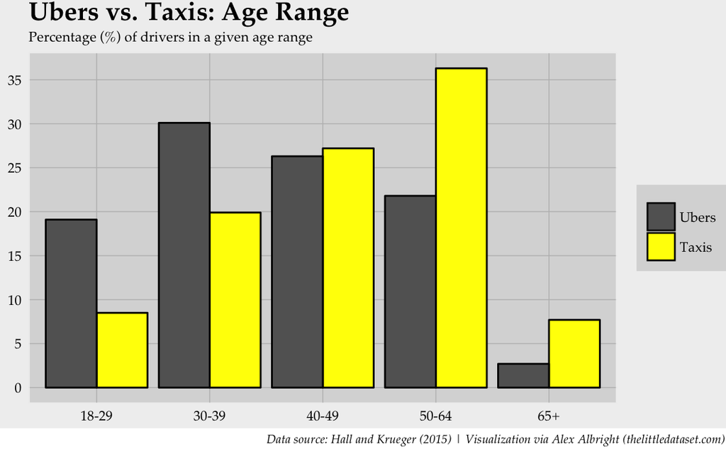

```r
age <- read.csv('raw_data/age.csv')
newage<-melt(age, id=c("Attribute"))
#set colors for uber and taxi driver bars
pal2 <- c("#636363", "#ffff00")
#plot graph
age<-ggplot(data=newage, aes(x=Attribute, y=value, fill=variable))+
    geom_bar(stat="identity", position=position_dodge(), colour="black")+
    scale_fill_manual(values = pal2) +
    theme(legend.key = element_rect(colour = "black"))+
    my_theme()+
    guides(fill = guide_legend(override.aes = list(colour = NULL)))+
    scale_y_continuous(breaks=seq(0,40,5))+
    ggtitle("Ubers vs. Taxis: Age Range", subtitle="Percentage (%) of drivers in a given age range")
#add source and credit
grid.arrange(age, ncol=1, nrow=1, bottom=textGrob("Data source: Hall and Krueger (2015) | Visualization via Alex Albright (thelittledataset.com)", hjust=.21, gp=gpar(fontsize=7, font=3, fontfamily="Palatino")))
```

Save to pdf

```r
#save to pdf
pdf("age.pdf", width = 6, height = 4) # Open a new pdf file
grid.arrange(age, ncol=1, nrow=1, bottom=textGrob("Data source: Hall and Krueger (2015) | Visualization via Alex Albright (thelittledataset.com)", hjust=.21, gp=gpar(fontsize=7, font=3, fontfamily="Palatino")))
dev.off()
```

## 2. Hours worked

Load data and plot:

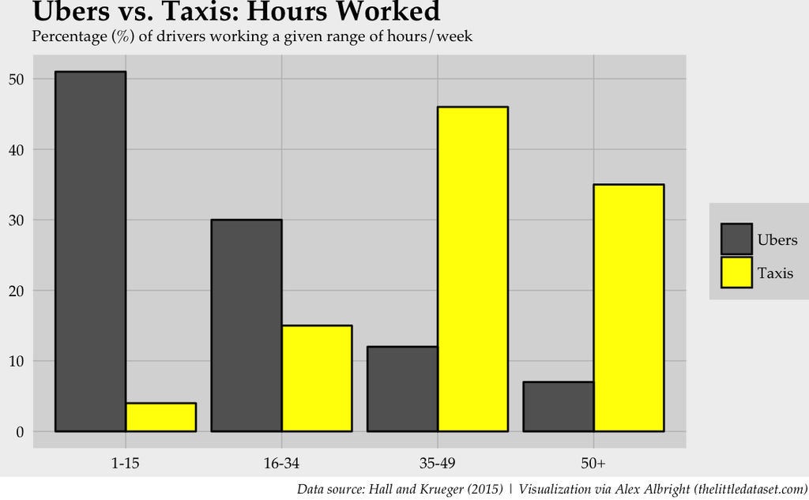

```r
h <- read.csv('raw_data/hours.csv')
hour<-melt(h, id=c("Attribute"))
#set colors for uber and driver driver bars
pal2 <- c("#636363", "#ffff00")
#define graph
hours<-ggplot(data=hour, aes(x=Attribute, y=value, fill=variable))+
    geom_bar(stat="identity", position=position_dodge(), colour="black")+
    scale_fill_manual(values = pal2, guide_legend(colour="black")) +
    theme(legend.key = element_rect(colour = "black"))+
    my_theme()+
    guides(fill = guide_legend(override.aes = list(colour = NULL)))+
  ggtitle("Ubers vs. Taxis: Hours Worked", subtitle = "Percentage (%) of drivers working a given range of hours/week")+
  scale_x_discrete(labels=c("1-15", "16-34", "35-49", "50+"))
#add source and credit
grid.arrange(hours, ncol=1, nrow=1, bottom=textGrob("Data source: Hall and Krueger (2015) | Visualization via Alex Albright (thelittledataset.com)", hjust=.21, gp=gpar(fontsize=7, font=3, fontfamily="Palatino")))
```

Save to pdf

```r
#save to pdf
pdf("hours.pdf", width = 6, height = 4) # Open a new pdf file
grid.arrange(hours, ncol=1, nrow=1, bottom=textGrob("Data source: Hall and Krueger (2015) | Visualization via Alex Albright (thelittledataset.com)", hjust=.21, gp=gpar(fontsize=7, font=3, fontfamily="Palatino")))
dev.off()
```

## 3. Education level

Load data and plot:

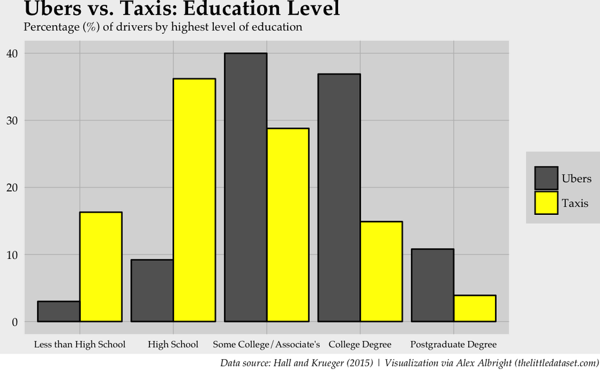

```r
ed <- read.csv('raw_data/education.csv')
newed<-melt(ed, id=c("Attribute"))
#set colors for uber and taxi driver bars
pal2 <- c("#636363", "#ffff00")
#plot graph
education<-ggplot(data=newed, aes(x=Attribute, y=value, fill=variable))+
    geom_bar(stat="identity", position=position_dodge(), colour="black")+
    scale_fill_manual(values = pal2, guide_legend(colour="black")) +
    theme(legend.key = element_rect(colour = "black"))+
    my_theme()+
  theme(axis.text.x=element_text(size=6.5)) +
    guides(fill = guide_legend(override.aes = list(colour = NULL)))+
  scale_x_discrete(labels=c("Less than High School", "High School", "Some College/Associate's", "College Degree","Postgraduate Degree"))+
    ggtitle("Ubers vs. Taxis: Education Level", subtitle="Percentage (%) of drivers by highest level of education")
#add source and credit
grid.arrange(education, ncol=1, nrow=1, bottom=textGrob("Data source: Hall and Krueger (2015) | Visualization via Alex Albright (thelittledataset.com)", hjust=.21, gp=gpar(fontsize=7, font=3, fontfamily="Palatino")))
```

Save to pdf

```r
#save to pdf
pdf("educ.pdf", width = 6, height = 4) # Open a new pdf file
grid.arrange(education, ncol=1, nrow=1, bottom=textGrob("Data source: Hall and Krueger (2015) | Visualization via Alex Albright (thelittledataset.com)", hjust=.21, gp=gpar(fontsize=7, font=3, fontfamily="Palatino")))
dev.off()
```

## 4. Earnings by city

Load data and plot:

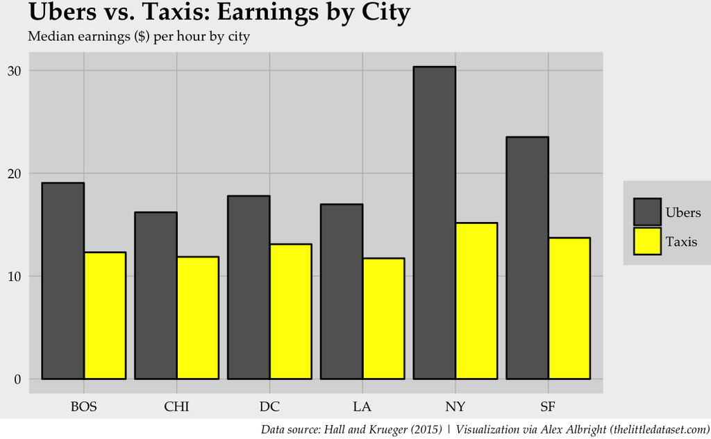

```r
#load data
ea <- read.csv('raw_data/earning.csv')
earn<-melt(ea, id=c("Attribute"))
#set colors for uber and taxi driver bars
pal2 <- c("#636363", "#ffff00")
#plot graph
ear<-ggplot(data=earn, aes(x=Attribute, y=value, fill=variable))+
    geom_bar(stat="identity", position=position_dodge(), colour="black")+
    scale_fill_manual(values = pal2, guide_legend(colour="black")) +
    theme(legend.key = element_rect(colour = "black"))+
    my_theme()+
    guides(fill = guide_legend(override.aes = list(colour = NULL)))+
    ggtitle("Ubers vs. Taxis: Earnings by City", subtitle="Median earnings ($) per hour by city")
#add source and credit
grid.arrange(ear, ncol=1, nrow=1, bottom=textGrob("Data source: Hall and Krueger (2015) | Visualization via Alex Albright (thelittledataset.com)", hjust=.21, gp=gpar(fontsize=7, font=3, fontfamily="Palatino")))
```

Save to pdf

```r
#save to pdf
pdf("earning_by_city.pdf", width = 6, height = 4) # Open a new pdf file
grid.arrange(ear, ncol=1, nrow=1, bottom=textGrob("Data source: Hall and Krueger (2015) | Visualization via Alex Albright (thelittledataset.com)", hjust=.21, gp=gpar(fontsize=7, font=3, fontfamily="Palatino")))
dev.off()
```

## 5. Hours worked by city

Load data and plot:

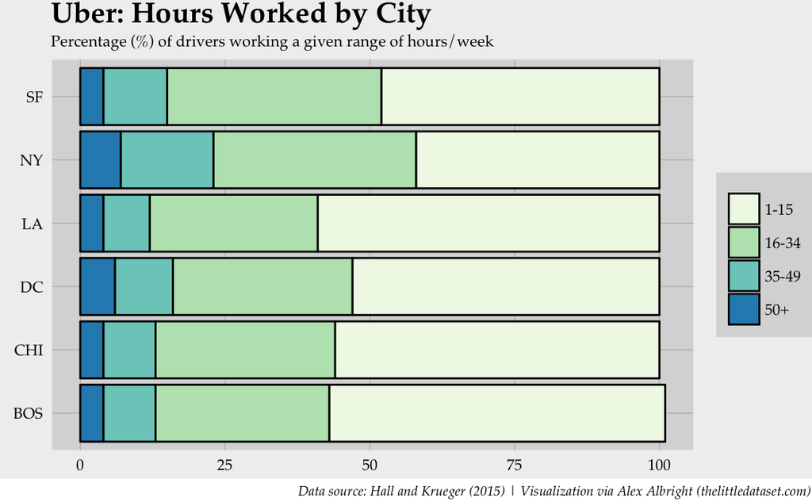

```r
ed <- read.csv('raw_data/citiesuberx.csv')
cit<-melt(ed, id=c("City"))
#plot graph
city<-ggplot(data = cit, aes(x = City, y=value, fill = variable)) +
    geom_bar(stat="identity", colour="black")+ coord_flip()+
    theme(legend.key = element_rect(colour = "black"))+
    my_theme()+
    guides(fill = guide_legend(override.aes = list(colour = NULL)))+
    scale_fill_brewer(palette="GnBu", name ="Hours/Week", breaks=c("X1.to.15", "X16.to.34","X35.to.49","X50.or.more"), labels=c("1-15", "16-34","35-49","50+"))+
    ggtitle("Uber: Hours Worked by City", subtitle="Percentage (%) of drivers working a given range of hours/week")
#add source and credit
grid.arrange(city, ncol=1, nrow=1, bottom=textGrob("Data source: Hall and Krueger (2015) | Visualization via Alex Albright (thelittledataset.com)", hjust=.21, gp=gpar(fontsize=7, font=3, fontfamily="Palatino")))
```

Save to pdf

```r
#save to pdf
pdf("city.pdf", width = 6, height = 4) # Open a new pdf file
grid.arrange(city, ncol=1, nrow=1, bottom=textGrob("Data source: Hall and Krueger (2015) | Visualization via Alex Albright (thelittledataset.com)", hjust=.21, gp=gpar(fontsize=7, font=3, fontfamily="Palatino")))
dev.off()
```

## 6. Race

Load data and plot:

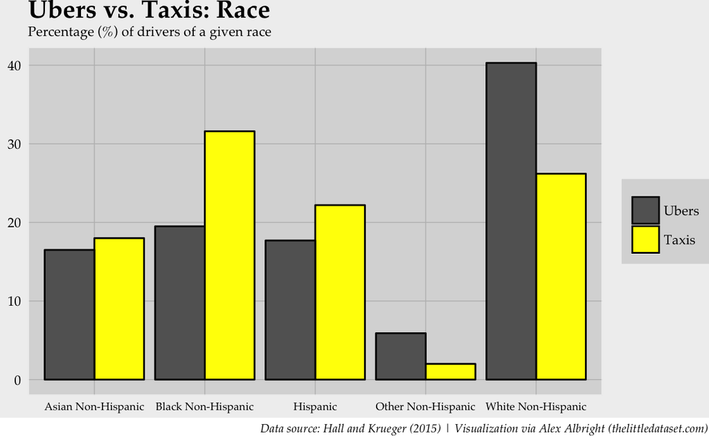

```r
race <- read.csv('raw_data/race.csv')
newrace<-melt(race, id=c("Attribute"))
#set colors for uber and taxi driver bars
pal2 <- c("#636363", "#ffff00")
#plot graph
race<-ggplot(data=newrace, aes(x=Attribute, y=value, fill=variable))+
    geom_bar(stat="identity", position=position_dodge(), colour="black")+
    scale_fill_manual(values = pal2, guide_legend(colour="black")) +
    theme(legend.key = element_rect(colour = "black"))+
    my_theme()+
  theme(axis.text.x=element_text(size=6.5)) +
    guides(fill = guide_legend(override.aes = list(colour = NULL)))+
    ggtitle("Ubers vs. Taxis: Race", subtitle="Percentage (%) of drivers of a given race")
#add source and credit
grid.arrange(race, ncol=1, nrow=1, bottom=textGrob("Data source: Hall and Krueger (2015) | Visualization via Alex Albright (thelittledataset.com)", hjust=.21, gp=gpar(fontsize=7, font=3, fontfamily="Palatino")))
```

Save to pdf

```r
#save to pdf
pdf("race.pdf", width = 6, height = 4) # Open a new pdf file
grid.arrange(race, ncol=1, nrow=1, bottom=textGrob("Data source: Hall and Krueger (2015) | Visualization via Alex Albright (thelittledataset.com)", hjust=.21, gp=gpar(fontsize=7, font=3, fontfamily="Palatino")))
dev.off()
```

## 7. Gender

Load data and plot:

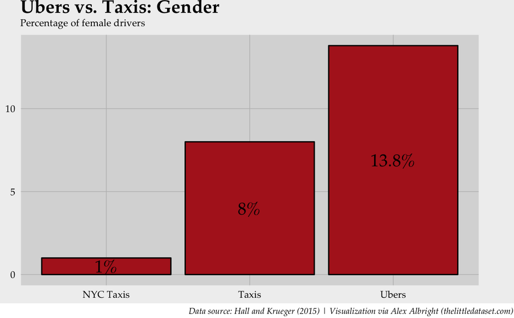

```r
#load numbers--since it's only three percentages it's not worth loading in the gender.csv file
DF <- data.frame(type = c("Ubers","Taxis","NYC Taxis"), per = c(13.8,8,1))

#place percentages in the middle of the bars
 DF <- ddply(DF, .(type), transform, pos = cumsum(per) - (0.5 * per))

#plot graph
fem<-ggplot(DF, aes(x = type, y = per)) +
    my_theme()+
    geom_bar(stat = "identity", fill = "firebrick", colour="black") +
    labs(title= "Ubers vs. Taxis: Gender \nPercentage of female drivers", x="", y="")+
    ggtitle("Ubers vs. Taxis: Gender", subtitle="Percentage of female drivers") +
  theme(plot.margin = unit(c(0, 1, 0, 0), "cm"))+
  geom_text(aes(label = c("1%", "8%","13.8%"), y = pos), size = 5, family="Palatino", face="bold")
#add source and credit
grid.arrange(fem, ncol=1, nrow=1, bottom=textGrob("Data source: Hall and Krueger (2015) | Visualization via Alex Albright (thelittledataset.com)", hjust=.21, gp=gpar(fontsize=7, font=3, fontfamily="Palatino")))
```

Save to pdf

```r
#save to pdf
pdf("gender.pdf", width = 6, height = 4) # Open a new pdf file
grid.arrange(fem, ncol=1, nrow=1, bottom=textGrob("Data source: Hall and Krueger (2015) | Visualization via Alex Albright (thelittledataset.com)", hjust=.21, gp=gpar(fontsize=7, font=3, fontfamily="Palatino")))
dev.off()
```

We have now finished plotting/saving all the graphs in the article.